# Compte rendu

#Mise en place des données

```r
library(readxl)
library(dplyr)
library(tidyverse)
library(missMDA)
questionnaire <- read_excel("~/stage/Stage/questionnaire.xlsx")
head(questionnaire)
```

```
## # A tibble: 6 × 55
##   Individu Lycée    Classe Sexe  APSA     Q1    Q2    Q3    Q4    Q5    Q6    Q7
##      <dbl> <chr>    <chr>  <chr> <chr> <dbl> <dbl> <dbl> <dbl> <dbl> <dbl> <dbl>
## 1        1 Victor … 2nd    F     Esca…     5     4     4     4     5     5     3
## 2        2 Victor … 2nd    F     Esca…     4     4     5     3     4     4     4
## 3        3 Victor … 2nd    F     Esca…     4     4     5     4     4     3     1
## 4        4 Victor … 2nd    M     Esca…     4     5     4     3     5     4     4
## 5        5 Victor … 2nd    M     Esca…     5     5     5     5     5     5     1
## 6        6 Victor … 2nd    M     Esca…     4     4     4     4     4     4     4
## # ℹ 43 more variables: Q8 <dbl>, Q9 <dbl>, Q10 <dbl>, Q11 <dbl>, Q12 <dbl>,
## #   Q13 <dbl>, Q14 <dbl>, Q15 <dbl>, Q16 <dbl>, Q17 <dbl>, Q18 <dbl>,
## #   Q19 <dbl>, Q20 <dbl>, Q21 <dbl>, Q22 <dbl>, Q23 <dbl>, Q24 <dbl>,
## #   Q25 <dbl>, Q26 <dbl>, Q27 <dbl>, Q28 <dbl>, Q29 <dbl>, Q30 <dbl>,
## #   Q31 <dbl>, Q32 <dbl>, Q33 <dbl>, Q34 <dbl>, Q35 <dbl>, Q36 <dbl>,
## #   Q37 <dbl>, Q38 <dbl>, Q39 <dbl>, Q40 <dbl>, Q41 <dbl>, Q42 <dbl>,
## #   Q43 <dbl>, Q44 <dbl>, Q45 <dbl>, Q46 <dbl>, Q47 <dbl>, Q48 <dbl>, …
```

```r
QPE4PL = questionnaire %>% select(-Individu, -Lycée, -Classe, -Sexe, -APSA)



nb <- estim_ncpPCA(QPE4PL)
colonnesimputees <- imputePCA (QPE4PL, ncp=nb$ncp)
QPE4PLm <- colonnesimputees$completeObs[, 1:50]

library(psych)
QPE4PLlesson =QPE4PLm[,1:23]
QPE4PLimpact = QPE4PLm[,24:50]
```

# Dimentionnalité

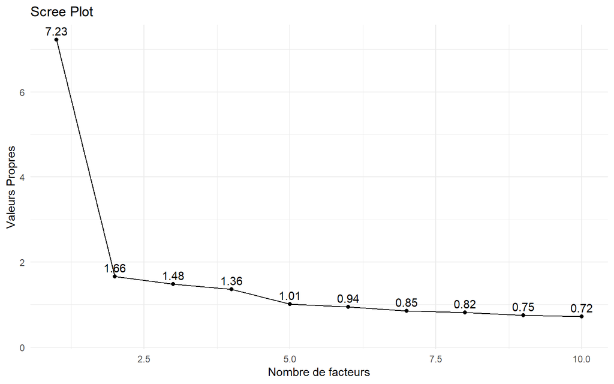

```r
lessonct <- na.omit(as.data.frame(scale(QPE4PLlesson))) #données centré réduite
QPE4PLl_EFA_cor <- cor(lessonct, use = "pairwise.complete.obs")
vp = eigen(QPE4PLl_EFA_cor)$values


scree_data <- data.frame(
  Facteur = 1:length(vp),
  Valeur_Propre = vp
)

ggplot(scree_data, aes(x = Facteur, y = Valeur_Propre)) +
  geom_point() +
  geom_line() +
  geom_text(aes(label = round(Valeur_Propre, 2)), vjust = -0.5, hjust = 0.5) +
  labs(x = "Nombre de facteurs", y = "Valeurs Propres", title = "Scree Plot") +
  scale_x_continuous(limits = c(1,10 )) +  # Ajustez les limites de l'axe x selon vos besoins
  theme_minimal()
```

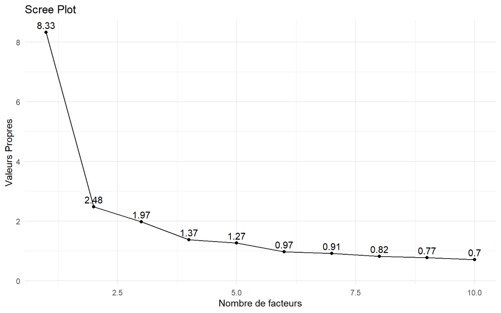

```r
impct <- na.omit(as.data.frame(scale(na.omit(QPE4PLimpact)))) #données centré réduite
QPE4PLi_EFA_cor <- cor(impct, use = "pairwise.complete.obs")
vp = eigen(QPE4PLi_EFA_cor)$values
#Méthode 1


scree_data <- data.frame(
  Facteur = 1:length(vp),
  Valeur_Propre = vp
)

ggplot(scree_data, aes(x = Facteur, y = Valeur_Propre)) +
  geom_point() +
  geom_line() +
  geom_text(aes(label = round(Valeur_Propre, 2)), vjust = -0.5, hjust = 0.5) +
  labs(x = "Nombre de facteurs", y = "Valeurs Propres", title = "Scree Plot") +
  scale_x_continuous(limits = c(1,10 )) +  # Ajustez les limites de l'axe x selon vos besoins
  theme_minimal()
```

# EFA lesson

```r
N <- nrow(QPE4PLlesson)

indices <- seq(1, N)

# Indices pairs et impairs
indices_EFAl <- indices[indices %% 2 == 0]
indices_CFAl <- indices[indices %% 2 != 0]

# Diviser le jeu de données en utilisant ces indices
QPE4Ll_EFA <- QPE4PLlesson[indices_EFAl, ]
QPE4Ll_CFA <- QPE4PLlesson[indices_CFAl, ]
```

On selectionne une personne sur deux, ca biaise pas car ca permets d’avoir autant de personne de même lycée dans chaque partie.

```r
#On pose le modèle avec 5 facteur pour la partie lesson
EFA_modelth<- fa(QPE4Ll_EFA, nfactors = 5)
#On regarde les charges factoriels
EFA_modelth$loadings
```

```
##
## Loadings:
##     MR1    MR2    MR3    MR4    MR5
## Q1                 0.726
## Q2                 0.720
## Q3          0.697
## Q4   0.115  0.659               -0.157
## Q5          0.329  0.288         0.117
## Q6          0.338                0.121
## Q7   0.509  0.193        -0.181  0.232
## Q8   0.484  0.176  0.198
## Q9   0.516  0.185        -0.165  0.261
## Q10  0.629                       0.153
## Q11  0.741                0.127 -0.130
## Q12  0.868
## Q13         0.317  0.108         0.153
## Q14         0.440 -0.104  0.317  0.162
## Q15  0.113  0.250  0.112
## Q16         0.263  0.211         0.355
## Q17         0.118  0.298  0.268  0.122
## Q18  0.580 -0.114  0.144  0.232
## Q19  0.125                0.780
## Q20         0.107         0.672  0.153
## Q21                       0.186  0.499
## Q22  0.116         0.369  0.121  0.439
## Q23                0.369  0.229  0.250
##
##                  MR1   MR2   MR3   MR4   MR5
## SS loadings    2.896 1.730 1.661 1.507 0.963
## Proportion Var 0.126 0.075 0.072 0.066 0.042
## Cumulative Var 0.126 0.201 0.273 0.339 0.381
```

```r
#On retir la question 14 (22 on peut pas car sinon pas 4 items par facteurs)
QPs =QPE4Ll_EFA[,-14]
library(psych)
# Exclure la question 14 du jeu de données
QPs_without_14 <- QPE4Ll_EFA[ , -14]

# Créer un nouveau modèle EFA avec 5 facteurs
EFA_modelth2 <- fa(QPs_without_14, nfactors = 5)

# Afficher les charges factorielles
print(EFA_modelth2$loadings)
```

```
##
## Loadings:
##     MR1    MR3    MR4    MR2    MR5
## Q1          0.728
## Q2          0.730
## Q3                 0.701
## Q4   0.112         0.654        -0.142
## Q5          0.263  0.335  0.115  0.132
## Q6                 0.317         0.122
## Q7   0.507         0.187 -0.167  0.238
## Q8   0.475  0.180  0.187
## Q9   0.510         0.184 -0.148  0.277
## Q10  0.619                       0.166
## Q11  0.744                0.118 -0.134
## Q12  0.868
## Q13                0.311  0.113  0.169
## Q15  0.117  0.113  0.231
## Q16         0.179  0.266         0.382
## Q17         0.263  0.137  0.290  0.143
## Q18  0.576  0.140 -0.110  0.232
## Q19  0.118                0.782
## Q20        -0.102  0.103  0.689  0.146
## Q21                       0.203  0.479
## Q22  0.114  0.357         0.137  0.436
## Q23         0.354         0.239  0.254
##
##                  MR1   MR3   MR4   MR2   MR5
## SS loadings    2.864 1.597 1.522 1.461 0.964
## Proportion Var 0.130 0.073 0.069 0.066 0.044
## Cumulative Var 0.130 0.203 0.272 0.338 0.382
```

On enlève la question 14 car admet des charges sur plusieurs facteurs

# CFA lesson

On part du modèle sans la question 14

```r
library(lavaan)
```

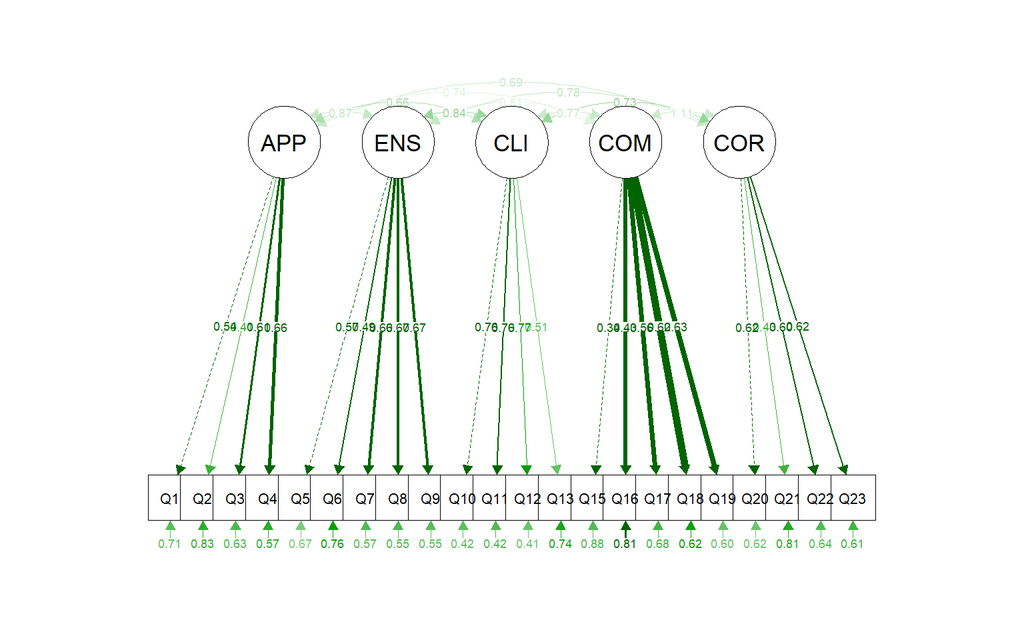

```r
library(semPlot)
modellesson <- "
    APP =~ Q1 + Q2 + Q3 + Q4
    ENS =~ Q5 + Q6 + Q7 + Q8 + Q9
    CLIM =~ Q10 + Q11 + Q12 + Q13
    COMO =~ Q15 + Q16 + Q17 + Q18 + Q19
    CORE =~ Q20 + Q21 + Q22 + Q23
"
#On pose le modèle
fitlesson <- cfa(model = modellesson, data = QPE4Ll_CFA,estimator = "MLM")
#Permet de creer le diagramme
semPaths(fitlesson, "est", "std.lv", layout = "tree", whatLabels = "std.lv", style = "lisrel")
```

```r
#permet de voir toute les statistiques et charge factoreil
summary(fitlesson, standardized = TRUE, fit.measures= TRUE, rsquare = TRUE)
```

```
## lavaan 0.6.17 ended normally after 73 iterations
##
##   Estimator                                         ML
##   Optimization method                           NLMINB
##   Number of model parameters                        54
##
##   Number of observations                           247
##
## Model Test User Model:
##                                               Standard      Scaled
##   Test Statistic                               497.516     384.611
##   Degrees of freedom                               199         199
##   P-value (Chi-square)                           0.000       0.000
##   Scaling correction factor                                  1.294
##     Satorra-Bentler correction
##
## Model Test Baseline Model:
##
##   Test statistic                              2043.223    1534.890
##   Degrees of freedom                               231         231
##   P-value                                        0.000       0.000
##   Scaling correction factor                                  1.331
##
## User Model versus Baseline Model:
##
##   Comparative Fit Index (CFI)                    0.835       0.858
##   Tucker-Lewis Index (TLI)                       0.809       0.835
##
##   Robust Comparative Fit Index (CFI)                         0.862
##   Robust Tucker-Lewis Index (TLI)                            0.839
##
## Loglikelihood and Information Criteria:
##
##   Loglikelihood user model (H0)              -7322.348   -7322.348
##   Loglikelihood unrestricted model (H1)      -7073.590   -7073.590
##
##   Akaike (AIC)                               14752.697   14752.697
##   Bayesian (BIC)                             14942.204   14942.204
##   Sample-size adjusted Bayesian (SABIC)      14771.024   14771.024
##
```

[output cut: 110 more lines]

```
##     Q8                0.447
##     Q9                0.449
##     Q10               0.576
##     Q11               0.581
##     Q12               0.585
##     Q13               0.260
##     Q15               0.116
##     Q16               0.189
##     Q17               0.318
##     Q18               0.385
##     Q19               0.401
##     Q20               0.378
##     Q21               0.188
##     Q22               0.358
##     Q23               0.390
```

```r
# Raccourci pour voir directement les indices qu'on veut plutot que de regarder dans le summary
fitMeasures(fitlesson, c("rmsea", "srmr", "cfi", "tli"))
```

```
## rmsea  srmr   cfi   tli
## 0.078 0.069 0.835 0.809
```

```r
loadings <- standardizedSolution(fitlesson)

# Filtrer uniquement les charges factorielles (lambdas)
loadings <- loadings[loadings$op == "=~", ]

# Afficher les charges factorielles
loadings[, c("lhs", "rhs", "est.std")]
```

```
##     lhs rhs est.std
## 1   APP  Q1   0.539
## 2   APP  Q2   0.407
## 3   APP  Q3   0.605
## 4   APP  Q4   0.657
## 5   ENS  Q5   0.571
## 6   ENS  Q6   0.487
## 7   ENS  Q7   0.655
## 8   ENS  Q8   0.669
## 9   ENS  Q9   0.670
## 10 CLIM Q10   0.759
## 11 CLIM Q11   0.762
## 12 CLIM Q12   0.765
## 13 CLIM Q13   0.510
## 14 COMO Q15   0.340
## 15 COMO Q16   0.435
## 16 COMO Q17   0.564
## 17 COMO Q18   0.620
## 18 COMO Q19   0.633
## 19 CORE Q20   0.615
## 20 CORE Q21   0.433
## 21 CORE Q22   0.599
## 22 CORE Q23   0.624
```

Le modèle est pas mal. On enlève la question 15 car la corrélation est très faible avec le facteur correspondant.

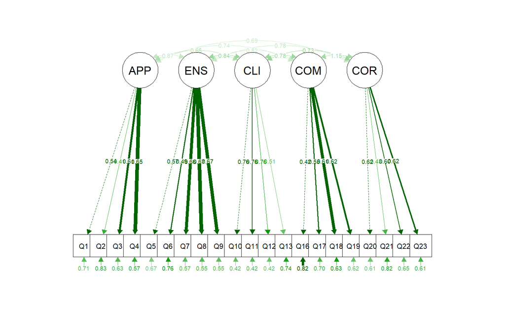

```r
library(lavaan)
library(semPlot)
modellesson2 <- "
    APP =~ Q1 + Q2 + Q3 + Q4
    ENS =~ Q5 + Q6 + Q7 + Q8 + Q9
    CLIM =~ Q10 + Q11 + Q12 + Q13
    COMO =~  Q16 + Q17 + Q18 + Q19
    CORE =~ Q20 + Q21 + Q22 + Q23
"

fitlesson2 <- cfa(model = modellesson2, data = QPE4Ll_CFA,estimator = "MLM")
semPaths(fitlesson2, "est", "std", layout = "tree", whatLabels = "est.std", style = "lisrel")
```

```r
summary(fitlesson2, standardized = TRUE, fit.measures= TRUE, rsquare = TRUE)
```

```
## lavaan 0.6.17 ended normally after 64 iterations
##
##   Estimator                                         ML
##   Optimization method                           NLMINB
##   Number of model parameters                        52
##
##   Number of observations                           247
##
## Model Test User Model:
##                                               Standard      Scaled
##   Test Statistic                               444.987     340.768
##   Degrees of freedom                               179         179
##   P-value (Chi-square)                           0.000       0.000
##   Scaling correction factor                                  1.306
##     Satorra-Bentler correction
##
## Model Test Baseline Model:
##
##   Test statistic                              1964.068    1467.491
##   Degrees of freedom                               210         210
##   P-value                                        0.000       0.000
##   Scaling correction factor                                  1.338
##
## User Model versus Baseline Model:
##
##   Comparative Fit Index (CFI)                    0.848       0.871
##   Tucker-Lewis Index (TLI)                       0.822       0.849
##
##   Robust Comparative Fit Index (CFI)                         0.874
##   Robust Tucker-Lewis Index (TLI)                            0.853
##
## Loglikelihood and Information Criteria:
##
##   Loglikelihood user model (H0)              -7017.192   -7017.192
##   Loglikelihood unrestricted model (H1)      -6794.698   -6794.698
##
##   Akaike (AIC)                               14138.384   14138.384
##   Bayesian (BIC)                             14320.872   14320.872
##   Sample-size adjusted Bayesian (SABIC)      14156.032   14156.032
##
```

[output cut: 107 more lines]

```
##     Q7                0.430
##     Q8                0.445
##     Q9                0.449
##     Q10               0.577
##     Q11               0.581
##     Q12               0.585
##     Q13               0.259
##     Q16               0.176
##     Q17               0.301
##     Q18               0.368
##     Q19               0.385
##     Q20               0.386
##     Q21               0.184
##     Q22               0.354
##     Q23               0.389
```

```r
fitMeasures(fitlesson2, c("rmsea", "srmr", "cfi", "tli"))
```

```
## rmsea  srmr   cfi   tli
## 0.078 0.069 0.848 0.822
```

On enlève la question 6

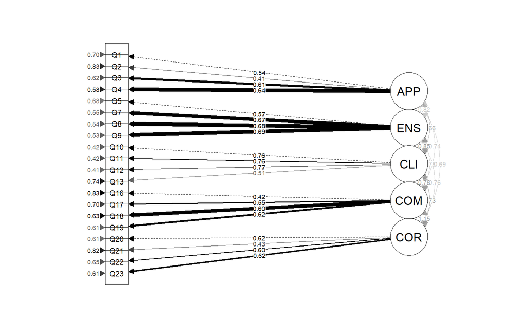

```r
library(lavaan)
library(semPlot)
library(fpc)
modellesson3 <- "
    APP =~ Q1 + Q2 + Q3 + Q4
    ENS =~ Q5  + Q7 + Q8 + Q9
    CLIM =~ Q10 + Q11 + Q12 + Q13
    COMO =~ Q16+  Q17 + Q18 + Q19
    CORE =~ Q20 + Q21 + Q22 + Q23
"

fitlesson3 <- cfa(model = modellesson3, data = QPE4Ll_CFA,estimator = "MLM")
semPaths(fitlesson3, "est", "std", layout = "tree", whatLabels = "est.std", style = "lisrel", edge.color = "black", rotation = 4)
```

```r
summary(fitlesson3, standardized = TRUE, fit.measures= TRUE, rsquare = TRUE)
```

```
## lavaan 0.6.17 ended normally after 64 iterations
##
##   Estimator                                         ML
##   Optimization method                           NLMINB
##   Number of model parameters                        50
##
##   Number of observations                           247
##
## Model Test User Model:
##                                               Standard      Scaled
##   Test Statistic                               398.000     302.449
##   Degrees of freedom                               160         160
##   P-value (Chi-square)                           0.000       0.000
##   Scaling correction factor                                  1.316
##     Satorra-Bentler correction
##
## Model Test Baseline Model:
##
##   Test statistic                              1862.796    1379.001
##   Degrees of freedom                               190         190
##   P-value                                        0.000       0.000
##   Scaling correction factor                                  1.351
##
## User Model versus Baseline Model:
##
##   Comparative Fit Index (CFI)                    0.858       0.880
##   Tucker-Lewis Index (TLI)                       0.831       0.858
##
##   Robust Comparative Fit Index (CFI)                         0.883
##   Robust Tucker-Lewis Index (TLI)                            0.861
##
## Loglikelihood and Information Criteria:
##
##   Loglikelihood user model (H0)              -6665.964   -6665.964
##   Loglikelihood unrestricted model (H1)      -6466.964   -6466.964
##
##   Akaike (AIC)                               13431.929   13431.929
##   Bayesian (BIC)                             13607.398   13607.398
##   Sample-size adjusted Bayesian (SABIC)      13448.899   13448.899
##
```

[output cut: 104 more lines]

```
##     Q7                0.450
##     Q8                0.459
##     Q9                0.474
##     Q10               0.579
##     Q11               0.576
##     Q12               0.586
##     Q13               0.260
##     Q16               0.173
##     Q17               0.303
##     Q18               0.366
##     Q19               0.387
##     Q20               0.387
##     Q21               0.185
##     Q22               0.354
##     Q23               0.386
```

```r
fitMeasures(fitlesson3, c("rmsea", "srmr", "cfi", "tli"))
```

```
## rmsea  srmr   cfi   tli
## 0.078 0.068 0.858 0.831
```

```r
library(semTools)
reliability(fitlesson3)
```

```
##              APP       ENS      CLIM      COMO      CORE
## alpha  0.6264413 0.7439542 0.7865693 0.6300071 0.6610643
## omega  0.6477828 0.7509744 0.8020166 0.6251003 0.6567202
## omega2 0.6477828 0.7509744 0.8020166 0.6251003 0.6567202
## omega3 0.6562516 0.7520051 0.8100418 0.6173344 0.6475884
## avevar 0.3269659 0.4358643 0.5123688 0.2981121 0.3286290
```

# Impact

```r
N <- nrow(QPE4PLimpact)
indices <- seq(1, N)

# Indices pairs et impairs
indices_EFA <- indices[indices %% 2 == 0]
indices_CFA <- indices[indices %% 2 != 0]



# Diviser le jeu de données en utilisant ces indices
QPE4Li_EFA <- QPE4PLimpact[indices_EFA, ]
QPE4Li_CFA <- QPE4PLimpact[indices_CFA, ]
```

```r
library(tidyverse)
library(dplyr)

#On creer le modèle avec 4 facteurs
EFA_modelth<- fa(QPE4Li_EFA, nfactors = 4)
#je regarde les charges factoriel, et je retire une à une les questions et regarde à nouveau les charges factoreil jusqu'a ce qu'il n'y est plus de questions répartie sur plusieurs facteusr
EFA_modelth$loadings
```

```
##
## Loadings:
##     MR1    MR3    MR2    MR4
## Q24  0.104                0.668
## Q25         0.139         0.363
## Q26                0.178  0.530
## Q27                0.132  0.715
## Q28  0.532         0.218
## Q29  0.842 -0.165
## Q30  0.577        -0.127  0.321
## Q31  0.909
## Q32  0.744  0.141
## Q33  0.523  0.227
## Q34  0.201  0.318         0.413
## Q35  0.119  0.387         0.368
## Q36         0.434  0.201
## Q37         0.344  0.271  0.193
## Q38  0.133  0.499  0.133 -0.218
## Q39  0.387  0.375  0.170 -0.157
## Q40  0.410  0.409        -0.141
## Q41         0.720
## Q42         0.735
## Q43         0.562         0.264
## Q44         0.426  0.263
## Q45  0.134  0.490  0.112
## Q46                0.658
## Q47                0.778
## Q48  0.104         0.720
## Q49                0.507  0.252
## Q50                0.453  0.203
##
##                  MR1   MR3   MR2   MR4
## SS loadings    3.434 3.048 2.408 2.116
## Proportion Var 0.127 0.113 0.089 0.078
## Cumulative Var 0.127 0.240 0.329 0.408
```

```r
# Je le transforme en dataframe pour pouvoir utliser la library dplyr
QPE4Li_EFA_df <- as.data.frame(QPE4Li_EFA)

# Load the dplyr library
library(dplyr)

QPs <- QPE4Li_EFA_df %>% select( -Q30, -Q34 , -Q40, -Q39)
EFA_modelth2<- fa(QPs, nfactors = 4)
EFA_modelth2$loadings
```

```
##
## Loadings:
##     MR1    MR3    MR2    MR4
## Q24                       0.794
## Q25         0.136         0.411
## Q26                0.113  0.567
## Q27                       0.743
## Q28  0.521         0.169  0.139
## Q29  0.820 -0.149
## Q31  0.907
## Q32  0.761  0.150
## Q33  0.531  0.227
## Q35  0.128  0.379         0.259
## Q36         0.427  0.199
## Q37         0.351  0.258  0.180
## Q38  0.140  0.471  0.128 -0.203
## Q41         0.700
## Q42         0.745 -0.108
## Q43         0.572         0.210
## Q44         0.442  0.268
## Q45  0.190  0.506  0.133
## Q46                0.641
## Q47                0.790
## Q48                0.762
## Q49                0.511  0.232
## Q50                0.444  0.197
##
##                  MR1   MR3   MR2   MR4
## SS loadings    2.735 2.623 2.358 1.984
## Proportion Var 0.119 0.114 0.103 0.086
## Cumulative Var 0.119 0.233 0.335 0.422
```

# CFA impact

On part du modèle sans les questions 30, 34, 39, 40

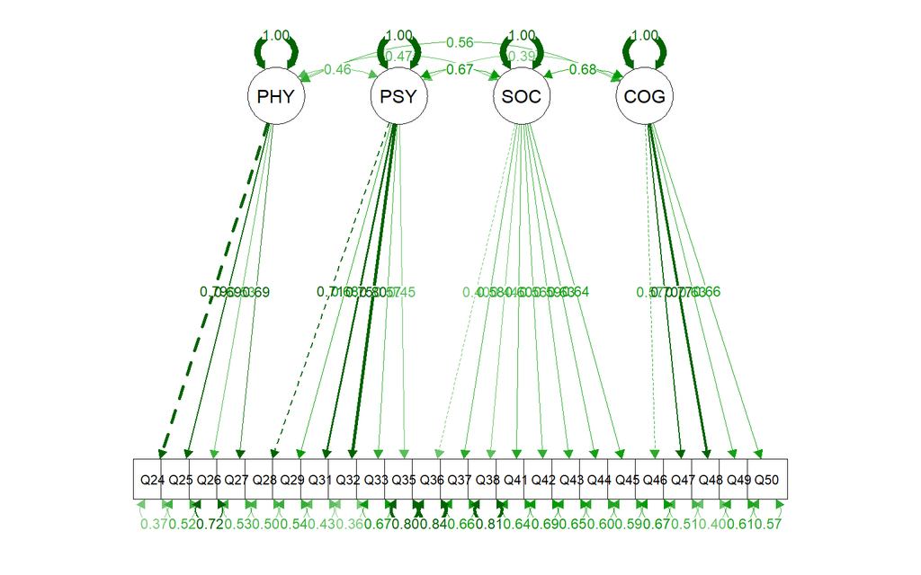

```r
model2 <- '
PHY =~ Q24 + Q25+ Q26+Q27 #Physique
PSY=~ Q28+ Q29+ Q31+ Q32+ Q33+ Q35 #Psychologique
SOC=~  Q36 +Q37+ Q38+ Q41 +Q42+ Q43+ Q44+ Q45 #Sociale
COG=~ Q46+ Q47+ Q48+ Q49+ Q50 #Cognitive '
library(lavaan)
#On créer le modèle
fit <- cfa(model2, data = QPE4Li_CFA,estimator = "MLM")
library(semPlot)
#On creer le diagramme
semPaths(fit, "std", layout = "tree", whatLabels = "std", edge.label.cex = 0.8, sizeMan = 5, sizeLat = 7)
```

```r
# Résumé des résultats
summary(fit, fit.measures = TRUE, standardized = TRUE)
```

```
## lavaan 0.6.17 ended normally after 50 iterations
##
##   Estimator                                         ML
##   Optimization method                           NLMINB
##   Number of model parameters                        52
##
##   Number of observations                           247
##
## Model Test User Model:
##                                               Standard      Scaled
##   Test Statistic                               564.385     445.087
##   Degrees of freedom                               224         224
##   P-value (Chi-square)                           0.000       0.000
##   Scaling correction factor                                  1.268
##     Satorra-Bentler correction
##
## Model Test Baseline Model:
##
##   Test statistic                              2249.993    1827.116
##   Degrees of freedom                               253         253
##   P-value                                        0.000       0.000
##   Scaling correction factor                                  1.231
##
## User Model versus Baseline Model:
##
##   Comparative Fit Index (CFI)                    0.830       0.860
##   Tucker-Lewis Index (TLI)                       0.807       0.841
##
##   Robust Comparative Fit Index (CFI)                         0.855
##   Robust Tucker-Lewis Index (TLI)                            0.837
##
## Loglikelihood and Information Criteria:
##
##   Loglikelihood user model (H0)              -8077.656   -8077.656
##   Loglikelihood unrestricted model (H1)      -7795.464   -7795.464
##
##   Akaike (AIC)                               16259.313   16259.313
##   Bayesian (BIC)                             16441.801   16441.801
##   Sample-size adjusted Bayesian (SABIC)      16276.961   16276.961
##
```

[output cut: 80 more lines]

```
##    .Q38               1.053    0.125    8.419    0.000    1.053    0.806
##    .Q41               1.074    0.119    9.046    0.000    1.074    0.644
##    .Q42               1.087    0.110    9.854    0.000    1.087    0.687
##    .Q43               0.859    0.107    8.060    0.000    0.859    0.655
##    .Q44               0.937    0.086   10.882    0.000    0.937    0.600
##    .Q45               0.808    0.090    8.942    0.000    0.808    0.591
##    .Q46               0.568    0.085    6.718    0.000    0.568    0.674
##    .Q47               0.407    0.063    6.443    0.000    0.407    0.505
##    .Q48               0.414    0.062    6.642    0.000    0.414    0.405
##    .Q49               0.578    0.069    8.385    0.000    0.578    0.608
##    .Q50               0.542    0.083    6.506    0.000    0.542    0.569
##     PHY               0.844    0.126    6.698    0.000    1.000    1.000
##     PSY               1.125    0.149    7.558    0.000    1.000    1.000
##     SOC               0.204    0.078    2.615    0.009    1.000    1.000
##     COG               0.275    0.069    3.974    0.000    1.000    1.000
```

```r
loadings <- standardizedSolution(fit)

# Filtrer uniquement les charges factorielles (lambdas)
loadings <- loadings[loadings$op == "=~", ]

# Afficher les charges factorielles
loadings[, c("lhs", "rhs", "est.std")]
```

```
##    lhs rhs est.std
## 1  PHY Q24   0.795
## 2  PHY Q25   0.694
## 3  PHY Q26   0.532
## 4  PHY Q27   0.688
## 5  PSY Q28   0.710
## 6  PSY Q29   0.675
## 7  PSY Q31   0.753
## 8  PSY Q32   0.800
## 9  PSY Q33   0.573
## 10 PSY Q35   0.446
## 11 SOC Q36   0.401
## 12 SOC Q37   0.582
## 13 SOC Q38   0.440
## 14 SOC Q41   0.596
## 15 SOC Q42   0.559
## 16 SOC Q43   0.587
## 17 SOC Q44   0.632
## 18 SOC Q45   0.640
## 19 COG Q46   0.571
## 20 COG Q47   0.703
## 21 COG Q48   0.772
## 22 COG Q49   0.626
## 23 COG Q50   0.657
```

```r
#On regarde les indices statistiques
fitMeasures(fit, c("rmsea", "srmr", "cfi", "tli","BIC"))
```

```
##     rmsea      srmr       cfi       tli       bic
##     0.078     0.070     0.830     0.807 16441.801
```

```r
library(semTools)
reliability(fit)
```

```
##              PHY       PSY       SOC       COG
## alpha  0.7694145 0.8196362 0.7833043 0.7998824
## omega  0.7730750 0.8281352 0.7843145 0.8020562
## omega2 0.7730750 0.8281352 0.7843145 0.8020562
## omega3 0.7714838 0.8315604 0.7791242 0.7999988
## avevar 0.4645621 0.4555461 0.3189700 0.4517101
```

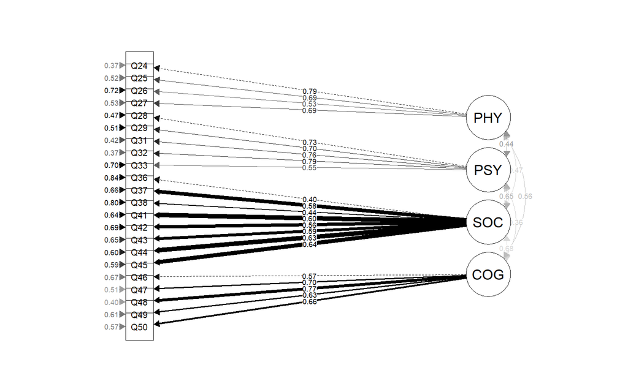

```r
model3 <- '
PHY =~ Q24 + Q25+ Q26+Q27 #Physique
PSY=~ Q28+ Q29+ Q31+ Q32+ Q33  #Psychologique
SOC=~ Q36+ Q37+ Q38+ Q41 +Q42+ Q43+ Q44+ Q45 #Sociale
COG=~ Q46+ Q47+ Q48+ Q49+ Q50 #Cognitive '
library(lavaan)
fit2 <- cfa(model3, data = QPE4Li_CFA,estimator = "MLM")
library(semPlot)
semPaths(fit2, "est", "std", layout = "tree", whatLabels = "est.std", style = "lisrel", edge.color = "black", rotation = 4)
```

```r
# Résumé des résultats pour voir charge factirel
summary(fit2, fit.measures = TRUE, standardized = TRUE)
```

```
## lavaan 0.6.17 ended normally after 48 iterations
##
##   Estimator                                         ML
##   Optimization method                           NLMINB
##   Number of model parameters                        50
##
##   Number of observations                           247
##
## Model Test User Model:
##                                               Standard      Scaled
##   Test Statistic                               495.879     389.754
##   Degrees of freedom                               203         203
##   P-value (Chi-square)                           0.000       0.000
##   Scaling correction factor                                  1.272
##     Satorra-Bentler correction
##
## Model Test Baseline Model:
##
##   Test statistic                              2136.229    1730.103
##   Degrees of freedom                               231         231
##   P-value                                        0.000       0.000
##   Scaling correction factor                                  1.235
##
## User Model versus Baseline Model:
##
##   Comparative Fit Index (CFI)                    0.846       0.875
##   Tucker-Lewis Index (TLI)                       0.825       0.858
##
##   Robust Comparative Fit Index (CFI)                         0.872
##   Robust Tucker-Lewis Index (TLI)                            0.854
##
## Loglikelihood and Information Criteria:
##
##   Loglikelihood user model (H0)              -7700.711   -7700.711
##   Loglikelihood unrestricted model (H1)      -7452.772   -7452.772
##
##   Akaike (AIC)                               15501.423   15501.423
##   Bayesian (BIC)                             15676.892   15676.892
##   Sample-size adjusted Bayesian (SABIC)      15518.393   15518.393
##
```

[output cut: 78 more lines]

```
##    .Q38               1.051    0.125    8.408    0.000    1.051    0.805
##    .Q41               1.070    0.119    9.012    0.000    1.070    0.642
##    .Q42               1.088    0.110    9.866    0.000    1.088    0.688
##    .Q43               0.857    0.107    8.010    0.000    0.857    0.653
##    .Q44               0.936    0.086   10.831    0.000    0.936    0.599
##    .Q45               0.812    0.090    8.977    0.000    0.812    0.594
##    .Q46               0.569    0.085    6.714    0.000    0.569    0.674
##    .Q47               0.408    0.063    6.448    0.000    0.408    0.506
##    .Q48               0.413    0.062    6.644    0.000    0.413    0.404
##    .Q49               0.577    0.069    8.384    0.000    0.577    0.607
##    .Q50               0.542    0.083    6.501    0.000    0.542    0.569
##     PHY               0.842    0.126    6.690    0.000    1.000    1.000
##     PSY               1.173    0.150    7.828    0.000    1.000    1.000
##     SOC               0.204    0.078    2.615    0.009    1.000    1.000
##     COG               0.275    0.069    3.972    0.000    1.000    1.000
```

```r
# Obtenir les indices de modification


fitMeasures(fit2, c("rmsea", "srmr", "cfi", "tli","BIC"))
```

```
##     rmsea      srmr       cfi       tli       bic
##     0.076     0.066     0.846     0.825 15676.892
```

```r
reliability(fit2)
```

```
##              PHY       PSY       SOC       COG
## alpha  0.7694145 0.8272027 0.7833043 0.7998824
## omega  0.7730775 0.8316601 0.7844711 0.8020604
## omega2 0.7730775 0.8316601 0.7844711 0.8020604
## omega3 0.7715314 0.8340134 0.7796380 0.7999966
## avevar 0.4645371 0.5008953 0.3191516 0.4517261
```

# Matrice de corrélation

```r
library(corrplot)
baseimputee <- cbind(questionnaire[, 1:5], QPE4PLm)





#création des scores des deux questionnaires
#création des scores des deux questionnaires
#QPE4PElesson

# Sélectionner les colonnes correspondant aux questions de chaque dimension
dimension1 <- baseimputee[, 6:9]
dimension2 <- baseimputee[, 10:14] %>% select(-Q6)
dimension3 <- baseimputee[, 15:19] %>% select(-Q14)
dimension4 <- baseimputee[, 20:23]%>% select(-Q15)
dimension5 <- baseimputee[, 24:28]

# Calculer les scores pour chaque dimension
baseimputee$score_objet_apprentissage <- rowSums(dimension1)
baseimputee$score_gestion_enseignement <- rowSums(dimension2)
baseimputee$score_climat_enseignement <- rowSums(dimension3)
baseimputee$score_activation_cognitivo_motrice <- rowSums(dimension4)
baseimputee$score_activation_cognitive_reflexive <- rowSums(dimension5)

# Calculer le score total (score_lesson) en additionnant les scores de chaque dimension
baseimputee$score_lesson <- rowSums(baseimputee[, c("score_objet_apprentissage", "score_gestion_enseignement", "score_climat_enseignement", "score_activation_cognitivo_motrice", "score_activation_cognitive_reflexive")])

#QPE4PLimpact

# Sélectionner les colonnes correspondant aux questions de chaque dimension pour la deuxième partie
score_physique <- baseimputee[, 29:32]
score_psycho <- baseimputee[, 33:41] %>% select(-Q30, -Q34, -Q35)
score_sociale <- baseimputee[, 42:51] %>% select(-Q39,-Q40)
score_cognitive <- baseimputee[, 52:55]

# Calculer les scores pour chaque dimension de la deuxième partie
baseimputee$score_physique <- rowSums(score_physique)
baseimputee$score_psycho <- rowSums(score_psycho)
baseimputee$score_sociale <- rowSums(score_sociale)
baseimputee$score_cognitive <- rowSums(score_cognitive)

# Calculer le score total pour la deuxième partie (score_impact)
baseimputee$score_impact <- rowSums(baseimputee[, c("score_physique", "score_psycho", "score_sociale", "score_cognitive")])

# Recherche de corrélation
# Entre le QPE4PLlesson et le QPE4PLimpact

# Sélectionner les variables pour la matrice de corrélation
variables_a_correler1 <- baseimputee[, c("score_lesson", "score_impact"
)]

# Calculer la matrice de corrélation
matrice_correlation1 <- cor(variables_a_correler1)

# Entre chaque dimension de chaque partie du questionnaire

# Sélectionner les variables pour la matrice de corrélation
variables_a_correler2 <- baseimputee[, c(
  "score_objet_apprentissage", "score_gestion_enseignement", "score_climat_enseignement", "score_activation_cognitivo_motrice", "score_activation_cognitive_reflexive", "score_lesson"
)]

# Calculer la matrice de corrélation
matrice_correlation2 <- cor(variables_a_correler2)

# Afficher les matrices de corrélation
print(matrice_correlation1)
```

```
##              score_lesson score_impact
## score_lesson    1.0000000    0.5965345
## score_impact    0.5965345    1.0000000
```

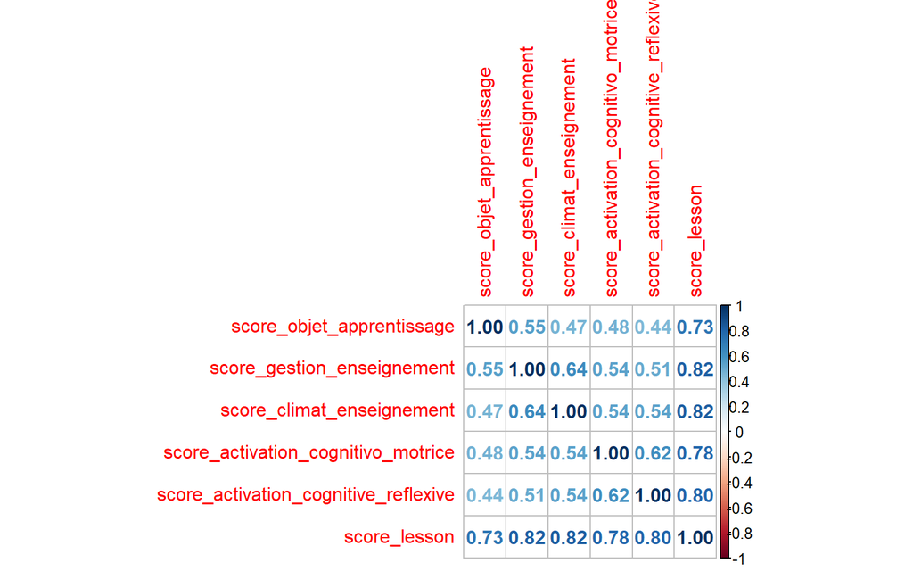

```r
corrplot (matrice_correlation2, method='number')
```

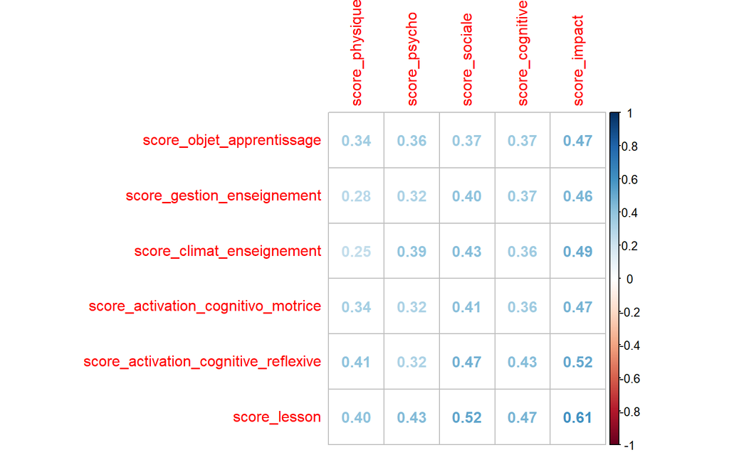

```r
#meilleur affichage des corrélations, à voir s'il faut renommer pour remplacer sans avoir de doublons de noms de variables
# Sélectionner les variables pour chaque partie
partie1 <- baseimputee[, c("score_objet_apprentissage", "score_gestion_enseignement", "score_climat_enseignement", "score_activation_cognitivo_motrice", "score_activation_cognitive_reflexive", "score_lesson")]
partie2 <- baseimputee[, c("score_physique", "score_psycho",
                           "score_sociale", "score_cognitive","score_impact")]



# à modifier remplacer verifier si les variables ne sont pas doublées
# Sélectionner les variables pour chaque partie
partie1 <- baseimputee[, c("score_objet_apprentissage", "score_gestion_enseignement", "score_climat_enseignement", "score_activation_cognitivo_motrice", "score_activation_cognitive_reflexive","score_lesson")]
partie2 <- baseimputee[, c("score_physique", "score_psycho",
                           "score_sociale", "score_cognitive","score_impact")]

# Calculer la matrice de corrélation entre les deux parties
matrice_correlation_entre_partiess <- cor(partie1, partie2, method = "spearman")

corrplot(matrice_correlation_entre_partiess, method = "number")
```

```r
#permet de dire que cette corrélation est significative

cor.test(baseimputee$score_impact, baseimputee$score_lesson, method = "spearman")
```

```
##
##  Spearman's rank correlation rho
##
## data:  baseimputee$score_impact and baseimputee$score_lesson
## S = 7820398, p-value < 2.2e-16
## alternative hypothesis: true rho is not equal to 0
## sample estimates:
##       rho
## 0.6084014
```

#Structural equation modeling

```r
modellesson <- '
    APP =~ Q1 + Q2 + Q3 + Q4
    ENS =~ Q5 + Q7 + Q8 + Q9
    CLIM =~ Q10 + Q11 + Q12 + Q13
    COMO =~  Q16 + Q17 + Q18 + Q19
    CORE =~ Q20 + Q21 + Q22 + Q23
 '
# permet de poser le modèle
lesson.fit <- cfa(model = modellesson, data = QPE4PLlesson,estimator = "MLM")
#permet de regarder toute les stat et charges factoreil
summary(lesson.fit, standardized=T, fit.measures = TRUE)
```

```
## lavaan 0.6.17 ended normally after 59 iterations
##
##   Estimator                                         ML
##   Optimization method                           NLMINB
##   Number of model parameters                        50
##
##   Number of observations                           493
##
## Model Test User Model:
##                                               Standard      Scaled
##   Test Statistic                               727.105     536.528
##   Degrees of freedom                               160         160
##   P-value (Chi-square)                           0.000       0.000
##   Scaling correction factor                                  1.355
##     Satorra-Bentler correction
##
## Model Test Baseline Model:
##
##   Test statistic                              3415.967    2517.668
##   Degrees of freedom                               190         190
##   P-value                                        0.000       0.000
##   Scaling correction factor                                  1.357
##
## User Model versus Baseline Model:
##
##   Comparative Fit Index (CFI)                    0.824       0.838
##   Tucker-Lewis Index (TLI)                       0.791       0.808
##
##   Robust Comparative Fit Index (CFI)                         0.838
##   Robust Tucker-Lewis Index (TLI)                            0.808
##
## Loglikelihood and Information Criteria:
##
##   Loglikelihood user model (H0)             -13413.480  -13413.480
##   Loglikelihood unrestricted model (H1)     -13049.927  -13049.927
##
##   Akaike (AIC)                               26926.959   26926.959
##   Bayesian (BIC)                             27136.985   27136.985
##   Sample-size adjusted Bayesian (SABIC)      26978.284   26978.284
##
```

[output cut: 81 more lines]

```
##    .Q12               0.536    0.057    9.361    0.000    0.536    0.373
##    .Q13               0.930    0.065   14.322    0.000    0.930    0.797
##    .Q16               1.345    0.091   14.838    0.000    1.345    0.812
##    .Q17               0.748    0.062   12.020    0.000    0.748    0.703
##    .Q18               0.839    0.077   10.831    0.000    0.839    0.573
##    .Q19               0.605    0.055   11.065    0.000    0.605    0.632
##    .Q20               0.607    0.058   10.545    0.000    0.607    0.688
##    .Q21               0.842    0.074   11.386    0.000    0.842    0.813
##    .Q22               0.696    0.060   11.634    0.000    0.696    0.619
##    .Q23               0.763    0.068   11.169    0.000    0.763    0.598
##     APP               0.265    0.055    4.814    0.000    1.000    1.000
##     ENS               0.203    0.044    4.599    0.000    1.000    1.000
##     CLIM              0.724    0.086    8.419    0.000    1.000    1.000
##     COMO              0.311    0.069    4.505    0.000    1.000    1.000
##     CORE              0.275    0.053    5.239    0.000    1.000    1.000
```

```r
#affiche indice
fitMeasures(lesson.fit, c("rmsea", "srmr", "cfi", "tli"))
```

```
## rmsea  srmr   cfi   tli
## 0.085 0.069 0.824 0.791
```

```r
# permet de voir les modifications
# j'utlise ~~ qui sert à dire que deux questions sont corrélé
modificationindices(lesson.fit, sort = T)
```

```
##      lhs op rhs      mi    epc sepc.lv sepc.all sepc.nox
## 316  Q19 ~~ Q20 113.240  0.334   0.334    0.551    0.551
## 173   Q3 ~~  Q4  72.917  0.453   0.453    0.519    0.519
## 136   Q1 ~~  Q2  70.009  0.290   0.290    0.448    0.448
## 63   APP =~ Q13  50.492  1.079   0.555    0.514    0.514
## 155   Q2 ~~  Q3  45.655 -0.273  -0.273   -0.362   -0.362
## 115 COMO =~ Q13  43.385  1.254   0.699    0.647    0.647
## 56   APP =~  Q5  41.818  1.186   0.610    0.699    0.699
## 131 CORE =~ Q13  32.057  0.907   0.476    0.440    0.440
## 98  CLIM =~ Q18  29.059  0.644   0.548    0.453    0.453
## 86   ENS =~ Q22  28.786  1.011   0.455    0.430    0.430
## 271  Q11 ~~ Q12  26.265  0.247   0.247    0.414    0.414
## 138   Q1 ~~  Q4  25.477 -0.230  -0.230   -0.307   -0.307
## 92  CLIM =~  Q5  21.909 -0.531  -0.452   -0.518   -0.518
## 321  Q20 ~~ Q22  19.233 -0.160  -0.160   -0.246   -0.246
```

[output cut: 258 more lines]

```r
modellesson2 <- '
    APP =~ Q1 + Q2 + Q3 + Q4
    ENS =~  Q5+ Q7 + Q8 + Q9
    CLIM =~ Q10 + Q11 + Q12 + Q13
    COMO =~  Q16 + Q17 + Q18 + Q19
    CORE =~ Q20 + Q21 + Q22 + Q23
    Q19 ~~  Q20
    Q3  ~~  Q4
 '

lesson.fit2 <- cfa(model = modellesson2, data = QPE4PLlesson, estimator = "MLM")
summary(lesson.fit2,standardized=T, fit.measures = TRUE)
```

```
## lavaan 0.6.17 ended normally after 62 iterations
##
##   Estimator                                         ML
##   Optimization method                           NLMINB
##   Number of model parameters                        52
##
##   Number of observations                           493
##
## Model Test User Model:
##                                               Standard      Scaled
##   Test Statistic                               547.171     409.963
##   Degrees of freedom                               158         158
##   P-value (Chi-square)                           0.000       0.000
##   Scaling correction factor                                  1.335
##     Satorra-Bentler correction
##
## Model Test Baseline Model:
##
##   Test statistic                              3415.967    2517.668
##   Degrees of freedom                               190         190
##   P-value                                        0.000       0.000
##   Scaling correction factor                                  1.357
##
## User Model versus Baseline Model:
##
##   Comparative Fit Index (CFI)                    0.879       0.892
##   Tucker-Lewis Index (TLI)                       0.855       0.870
##
##   Robust Comparative Fit Index (CFI)                         0.894
##   Robust Tucker-Lewis Index (TLI)                            0.872
##
## Loglikelihood and Information Criteria:
##
##   Loglikelihood user model (H0)             -13323.512  -13323.512
##   Loglikelihood unrestricted model (H1)     -13049.927  -13049.927
##
##   Akaike (AIC)                               26751.024   26751.024
##   Bayesian (BIC)                             26969.451   26969.451
##   Sample-size adjusted Bayesian (SABIC)      26804.402   26804.402
##
```

[output cut: 85 more lines]

```
##    .Q12               0.531    0.057    9.328    0.000    0.531    0.369
##    .Q13               0.934    0.065   14.347    0.000    0.934    0.800
##    .Q16               1.332    0.091   14.678    0.000    1.332    0.804
##    .Q17               0.743    0.063   11.715    0.000    0.743    0.697
##    .Q18               0.794    0.080    9.910    0.000    0.794    0.542
##    .Q19               0.672    0.060   11.102    0.000    0.672    0.701
##    .Q20               0.688    0.065   10.628    0.000    0.688    0.778
##    .Q21               0.839    0.073   11.420    0.000    0.839    0.810
##    .Q22               0.603    0.056   10.843    0.000    0.603    0.537
##    .Q23               0.733    0.071   10.290    0.000    0.733    0.575
##     APP               0.376    0.071    5.298    0.000    1.000    1.000
##     ENS               0.192    0.043    4.465    0.000    1.000    1.000
##     CLIM              0.725    0.086    8.398    0.000    1.000    1.000
##     COMO              0.324    0.072    4.472    0.000    1.000    1.000
##     CORE              0.197    0.046    4.301    0.000    1.000    1.000
```

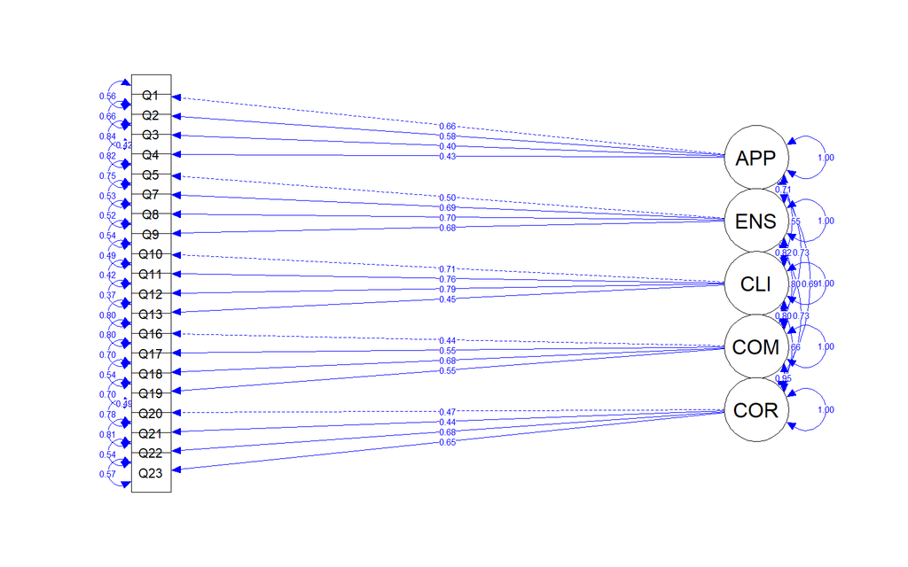

```r
semPaths(lesson.fit2,  whatLabels = "std.all",edge.label.cex = 0.5, rotation =4, edge.color ="blue")
```

```r
fitMeasures(lesson.fit2, c("rmsea", "srmr", "cfi", "tli"))
```

```
## rmsea  srmr   cfi   tli
## 0.071 0.068 0.879 0.855
```

Voici le modèle avec les corrélations

```r
model2 <- "
PHY =~ Q24 + Q25+ Q26+Q27 #Physique
PSY=~ Q28+ Q29+ Q31+ Q32+ Q33 #Psychologique
SOC=~ Q36+ Q37+ Q38+ Q41 +Q42+ Q43+ Q44+ Q45 #Sociale
COG=~ Q46+ Q47+ Q48+ Q49+ Q50 #Cognitive
"


lesson.fit <- cfa(model = model2, data = QPE4PLimpact, estimator = "MLM")
fitMeasures(lesson.fit, c("rmsea", "srmr", "cfi", "tli", "bic"))
```

```
##     rmsea      srmr       cfi       tli       bic
##     0.068     0.060     0.880     0.863 31010.549
```

```r
summary(lesson.fit, standardized=T, fit.measures = TRUE)
```

```
## lavaan 0.6.17 ended normally after 46 iterations
##
##   Estimator                                         ML
##   Optimization method                           NLMINB
##   Number of model parameters                        50
##
##   Number of observations                           493
##
## Model Test User Model:
##                                               Standard      Scaled
##   Test Statistic                               671.943     533.007
##   Degrees of freedom                               203         203
##   P-value (Chi-square)                           0.000       0.000
##   Scaling correction factor                                  1.261
##     Satorra-Bentler correction
##
## Model Test Baseline Model:
##
##   Test statistic                              4129.505    3321.041
##   Degrees of freedom                               231         231
##   P-value                                        0.000       0.000
##   Scaling correction factor                                  1.243
##
## User Model versus Baseline Model:
##
##   Comparative Fit Index (CFI)                    0.880       0.893
##   Tucker-Lewis Index (TLI)                       0.863       0.878
##
##   Robust Comparative Fit Index (CFI)                         0.892
##   Robust Tucker-Lewis Index (TLI)                            0.877
##
## Loglikelihood and Information Criteria:
##
##   Loglikelihood user model (H0)             -15350.262  -15350.262
##   Loglikelihood unrestricted model (H1)     -15014.290  -15014.290
##
##   Akaike (AIC)                               30800.524   30800.524
##   Bayesian (BIC)                             31010.549   31010.549
##   Sample-size adjusted Bayesian (SABIC)      30851.849   30851.849
##
```

[output cut: 78 more lines]

```
##    .Q38               1.022    0.086   11.857    0.000    1.022    0.768
##    .Q41               1.007    0.081   12.481    0.000    1.007    0.576
##    .Q42               0.936    0.075   12.447    0.000    0.936    0.593
##    .Q43               0.836    0.076   10.992    0.000    0.836    0.637
##    .Q44               0.973    0.075   12.921    0.000    0.973    0.623
##    .Q45               0.857    0.069   12.367    0.000    0.857    0.593
##    .Q46               0.498    0.054    9.306    0.000    0.498    0.637
##    .Q47               0.361    0.043    8.465    0.000    0.361    0.446
##    .Q48               0.416    0.043    9.625    0.000    0.416    0.407
##    .Q49               0.548    0.054   10.153    0.000    0.548    0.607
##    .Q50               0.580    0.061    9.588    0.000    0.580    0.624
##     PHY               0.857    0.088    9.782    0.000    1.000    1.000
##     PSY               1.054    0.110    9.621    0.000    1.000    1.000
##     SOC               0.228    0.056    4.053    0.000    1.000    1.000
##     COG               0.284    0.054    5.277    0.000    1.000    1.000
```

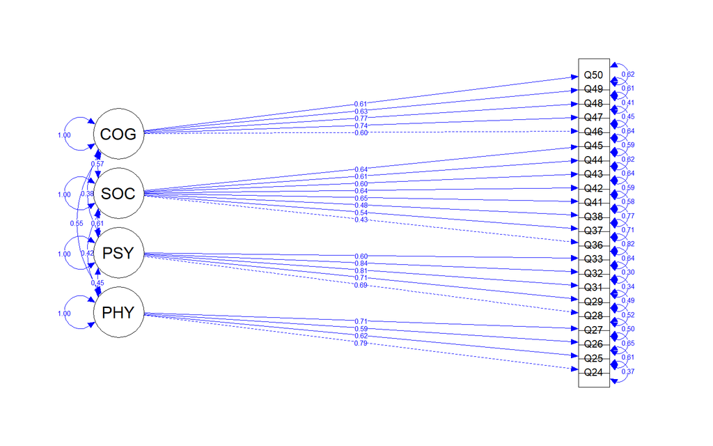

```r
semPaths(lesson.fit, whatLabels = "std.all", edge.label.cex = 0.5, rotation =2, edge.color ="blue")
```

```r
modificationindices(lesson.fit, sort = T)
```

```
##     lhs op rhs     mi    epc sepc.lv sepc.all sepc.nox
## 307 Q41 ~~ Q42 83.007  0.486   0.486    0.500    0.500
## 162 Q26 ~~ Q27 36.175  0.294   0.294    0.367    0.367
## 351 Q49 ~~ Q50 35.032  0.178   0.178    0.315    0.315
## 117 COG =~ Q42 33.041 -0.759  -0.404   -0.322   -0.322
## 61  PHY =~ Q37 30.687  0.386   0.357    0.286    0.286
## 114 COG =~ Q37 26.848  0.711   0.379    0.303    0.303
## 55  PHY =~ Q28 26.447  0.378   0.350    0.236    0.236
## 348 Q47 ~~ Q50 25.805 -0.139  -0.139   -0.304   -0.304
## 121 Q24 ~~ Q25 24.931  0.230   0.230    0.389    0.389
## 342 Q46 ~~ Q47 23.119  0.121   0.121    0.285    0.285
## 216 Q29 ~~ Q31 22.731  0.240   0.240    0.308    0.308
## 95  SOC =~ Q29 17.366 -0.640  -0.305   -0.218   -0.218
## 346 Q47 ~~ Q48 17.156  0.124   0.124    0.319    0.319
## 57  PHY =~ Q31 17.075 -0.250  -0.231   -0.170   -0.170
```

[output cut: 283 more lines]

```r
model3 <- "
PHY =~ Q24 + Q25+ Q26+Q27 #Physique
PSY=~ Q28+ Q29+ Q31+ Q32+ Q33 #Psychologique
SOC=~  Q36+Q37+ Q38+ Q41 +Q42+ Q43+ Q44+ Q45 #Sociale
COG=~ Q46+ Q47+ Q48+ Q49+ Q50 #Cognitive
Q41 ~~  Q42
Q26~~Q27
Q49~~Q50
"

lesson.fit2 <- cfa(model = model3, data = QPE4PLimpact, estimator = "MLM")
fitMeasures(lesson.fit2, c("rmsea", "srmr", "cfi", "tli", "bic"))
```

```
##     rmsea      srmr       cfi       tli       bic
##     0.057     0.055     0.918     0.905 30878.373
```

```r
summary(lesson.fit2, standardized=T, fit.measures = TRUE)
```

```
## lavaan 0.6.17 ended normally after 51 iterations
##
##   Estimator                                         ML
##   Optimization method                           NLMINB
##   Number of model parameters                        53
##
##   Number of observations                           493
##
## Model Test User Model:
##                                               Standard      Scaled
##   Test Statistic                               521.165     420.612
##   Degrees of freedom                               200         200
##   P-value (Chi-square)                           0.000       0.000
##   Scaling correction factor                                  1.239
##     Satorra-Bentler correction
##
## Model Test Baseline Model:
##
##   Test statistic                              4129.505    3321.041
##   Degrees of freedom                               231         231
##   P-value                                        0.000       0.000
##   Scaling correction factor                                  1.243
##
## User Model versus Baseline Model:
##
##   Comparative Fit Index (CFI)                    0.918       0.929
##   Tucker-Lewis Index (TLI)                       0.905       0.918
##
##   Robust Comparative Fit Index (CFI)                         0.929
##   Robust Tucker-Lewis Index (TLI)                            0.918
##
## Loglikelihood and Information Criteria:
##
##   Loglikelihood user model (H0)             -15274.873  -15274.873
##   Loglikelihood unrestricted model (H1)     -15014.290  -15014.290
##
##   Akaike (AIC)                               30655.746   30655.746
##   Bayesian (BIC)                             30878.373   30878.373
##   Sample-size adjusted Bayesian (SABIC)      30710.151   30710.151
##
```

[output cut: 84 more lines]

```
##    .Q38               1.031    0.088   11.755    0.000    1.031    0.775
##    .Q41               1.177    0.089   13.157    0.000    1.177    0.673
##    .Q42               1.093    0.083   13.101    0.000    1.093    0.693
##    .Q43               0.862    0.077   11.236    0.000    0.862    0.657
##    .Q44               0.922    0.075   12.300    0.000    0.922    0.590
##    .Q45               0.826    0.071   11.564    0.000    0.826    0.571
##    .Q46               0.488    0.053    9.238    0.000    0.488    0.624
##    .Q47               0.324    0.040    8.081    0.000    0.324    0.401
##    .Q48               0.411    0.048    8.539    0.000    0.411    0.402
##    .Q49               0.601    0.057   10.489    0.000    0.601    0.665
##    .Q50               0.633    0.065    9.739    0.000    0.633    0.681
##     PHY               0.964    0.094   10.277    0.000    1.000    1.000
##     PSY               1.056    0.110    9.635    0.000    1.000    1.000
##     SOC               0.235    0.058    4.079    0.000    1.000    1.000
##     COG               0.294    0.056    5.238    0.000    1.000    1.000
```

#modèle tout

Je mets tout ensemble pour créer un modèle qui relie tout les facteurs, tout comme la matrice des corrélation avec les score ca va permettre de regarder les relations entre les facteurs

```r
library(lavaan)
modeletout= '
    APP =~ Q1 + Q2 + Q3 + Q4
    ENS =~  Q5 + Q7 + Q8 + Q9
    CLIM =~ Q10 + Q11 + Q12 + Q13
    COMO =~  Q16 + Q17 + Q18 + Q19
    CORE =~ Q20 + Q21 + Q22 + Q23
    Q19 ~~ Q20
    Q3 ~~ Q4
    PHY =~ Q24 + Q25+ Q26+Q27 #Physique
PSY=~ Q28+ Q29+ Q31+ Q32+ Q33 #Psychologique
SOC=~ Q36+ Q37+ Q38+ Q41 +Q42+ Q43+ Q44+ Q45 #Sociale
COG=~ Q46+ Q47+ Q48+ Q49+ Q50 #Cognitive
Q41 ~~  Q42
Q26~~Q27
Q49~~Q50
 '

lesson.fittt <- cfa(model = modeletout, data = QPE4PLm, estimator = "MLM")
fitMeasures(lesson.fittt, c("rmsea", "srmr", "cfi", "tli", "bic"))
```

```
##     rmsea      srmr       cfi       tli       bic
##     0.054     0.064     0.856     0.841 57740.991
```

```r
summary(lesson.fittt, standardized=T, fit.measures = TRUE)
```

```
## lavaan 0.6.17 ended normally after 117 iterations
##
##   Estimator                                         ML
##   Optimization method                           NLMINB
##   Number of model parameters                       125
##
##   Number of observations                           493
##
## Model Test User Model:
##                                               Standard      Scaled
##   Test Statistic                              1890.145    1517.259
##   Degrees of freedom                               778         778
##   P-value (Chi-square)                           0.000       0.000
##   Scaling correction factor                                  1.246
##     Satorra-Bentler correction
##
## Model Test Baseline Model:
##
##   Test statistic                              8598.124    6902.488
##   Degrees of freedom                               861         861
##   P-value                                        0.000       0.000
##   Scaling correction factor                                  1.246
##
## User Model versus Baseline Model:
##
##   Comparative Fit Index (CFI)                    0.856       0.878
##   Tucker-Lewis Index (TLI)                       0.841       0.865
##
##   Robust Comparative Fit Index (CFI)                         0.878
##   Robust Tucker-Lewis Index (TLI)                            0.865
##
## Loglikelihood and Information Criteria:
##
##   Loglikelihood user model (H0)             -28482.964  -28482.964
##   Loglikelihood unrestricted model (H1)     -27537.891  -27537.891
##
##   Akaike (AIC)                               57215.927   57215.927
##   Bayesian (BIC)                             57740.991   57740.991
##   Sample-size adjusted Bayesian (SABIC)      57344.240   57344.240
##
```

[output cut: 173 more lines]

```
##    .Q45               0.836    0.071   11.804    0.000    0.836    0.579
##    .Q46               0.475    0.052    9.103    0.000    0.475    0.608
##    .Q47               0.315    0.039    8.071    0.000    0.315    0.389
##    .Q48               0.422    0.047    9.075    0.000    0.422    0.414
##    .Q49               0.611    0.057   10.726    0.000    0.611    0.677
##    .Q50               0.645    0.066    9.794    0.000    0.645    0.694
##     APP               0.287    0.058    4.941    0.000    1.000    1.000
##     ENS               0.204    0.044    4.589    0.000    1.000    1.000
##     CLIM              0.727    0.086    8.479    0.000    1.000    1.000
##     COMO              0.335    0.072    4.630    0.000    1.000    1.000
##     CORE              0.244    0.049    4.982    0.000    1.000    1.000
##     PHY               0.926    0.091   10.189    0.000    1.000    1.000
##     PSY               1.069    0.109    9.794    0.000    1.000    1.000
##     SOC               0.239    0.058    4.130    0.000    1.000    1.000
##     COG               0.307    0.058    5.318    0.000    1.000    1.000
```

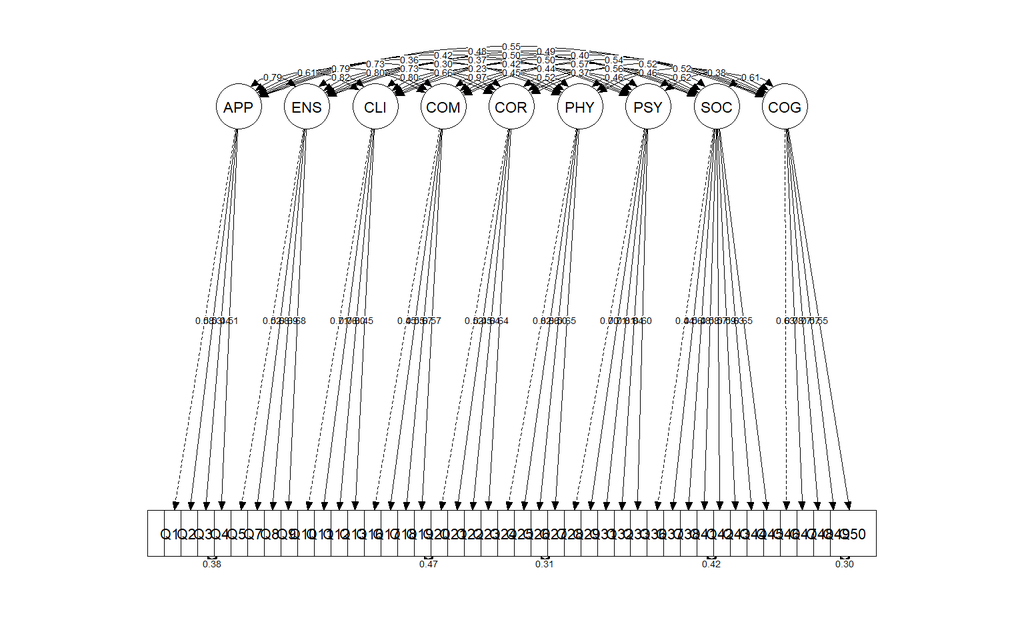

```r
semPaths(object = lesson.fittt,
         layout = "tree",
         rotation = 1,
         whatLabels = "std",
         edge.label.cex = 0.45,
         edge.color = "black",
         residuals = FALSE,
         sizeLat = 5)
```

Rassemble les deux modèle pour étudier les corrélation entre facteurs (le sempaths permet de bien comprendre) On regrade alors les endroits comme APP ~~ ENS qui montre la relation entre apprentissage et enseignment dans le summary (~~ désigne la corrélation)

On fait pareil mais en comparant la partie LESSON et IMPACT, je créér donc deux nouveaux facteurs pour relier les 5 facterus de lesson et les 4 de impact. Enseuite j’étudie dans le summary la relation LESSON et IMPACT

```r
library(lavaan)
library(semPlot)
modelett2= '
    APP =~ Q1 + Q2 + Q3 + Q4
    ENS =~  Q5 + Q7 + Q8 + Q9
    CLIM =~ Q10 + Q11 + Q12 + Q13
    COMO =~   Q16 + Q17 + Q18 + Q19
    CORE =~ Q20 + Q21 + Q22 + Q23
    Q19 ~~ Q20
    Q3 ~~ Q4
    LESSON =~ APP + ENS + CLIM + COMO + CORE
    PHY =~ Q24 + Q25+ Q26+Q27 #Physique
PSY=~ Q28+ Q29+ Q31+ Q32+ Q33 #Psychologique
SOC=~ Q36+ Q37+ Q38+ Q41 +Q42+ Q43+ Q44+ Q45 #Sociale
COG=~ Q46+ Q47+ Q48+ Q49+ Q50 #Cognitive
Q41 ~~  Q42
Q26~~Q27
Q49~~Q50
IMPACT = ~ PHY + PSY + SOC + COG
IMPACT ~ LESSON
 '

lesson.fittt <- cfa(model = modelett2, data = QPE4PLm, estimator = "MLM")
fitMeasures(lesson.fittt, c("rmsea", "srmr", "cfi", "tli", "bic"))
```

```
##     rmsea      srmr       cfi       tli       bic
##     0.055     0.070     0.844     0.833 57697.333
```

```r
summary(lesson.fittt, standardized=T, fit.measures = TRUE)
```

```
## lavaan 0.6.17 ended normally after 61 iterations
##
##   Estimator                                         ML
##   Optimization method                           NLMINB
##   Number of model parameters                        99
##
##   Number of observations                           493
##
## Model Test User Model:
##                                               Standard      Scaled
##   Test Statistic                              2007.700    1609.871
##   Degrees of freedom                               804         804
##   P-value (Chi-square)                           0.000       0.000
##   Scaling correction factor                                  1.247
##     Satorra-Bentler correction
##
## Model Test Baseline Model:
##
##   Test statistic                              8598.124    6902.488
##   Degrees of freedom                               861         861
##   P-value                                        0.000       0.000
##   Scaling correction factor                                  1.246
##
## User Model versus Baseline Model:
##
##   Comparative Fit Index (CFI)                    0.844       0.867
##   Tucker-Lewis Index (TLI)                       0.833       0.857
##
##   Robust Comparative Fit Index (CFI)                         0.866
##   Robust Tucker-Lewis Index (TLI)                            0.857
##
## Loglikelihood and Information Criteria:
##
##   Loglikelihood user model (H0)             -28541.741  -28541.741
##   Loglikelihood unrestricted model (H1)     -27537.891  -27537.891
##
##   Akaike (AIC)                               57281.482   57281.482
##   Bayesian (BIC)                             57697.333   57697.333
##   Sample-size adjusted Bayesian (SABIC)      57383.106   57383.106
##
```

[output cut: 147 more lines]

```
##    .Q47               0.316    0.039    8.022    0.000    0.316    0.390
##    .Q48               0.415    0.049    8.450    0.000    0.415    0.407
##    .Q49               0.610    0.058   10.601    0.000    0.610    0.676
##    .Q50               0.645    0.066    9.782    0.000    0.645    0.694
##    .APP               0.130    0.039    3.345    0.001    0.386    0.386
##    .ENS               0.049    0.015    3.210    0.001    0.232    0.232
##    .CLIM              0.235    0.043    5.440    0.000    0.326    0.326
##    .COMO              0.006    0.018    0.304    0.761    0.017    0.017
##    .CORE              0.036    0.014    2.543    0.011    0.185    0.185
##     LESSON            0.207    0.047    4.454    0.000    1.000    1.000
##    .PHY               0.588    0.087    6.796    0.000    0.620    0.620
##    .PSY               0.589    0.072    8.156    0.000    0.556    0.556
##    .SOC               0.067    0.021    3.212    0.001    0.275    0.275
##    .COG               0.145    0.031    4.720    0.000    0.481    0.481
##    .IMPACT            0.184    0.045    4.107    0.000    0.510    0.510
```

```r
modificationindices(lesson.fittt, sort = T)
```

```
##         lhs op    rhs     mi     epc sepc.lv sepc.all sepc.nox
## 531      Q1 ~~     Q2 59.990   0.330   0.330    0.587    0.587
## 384     PSY =~     Q4 46.646   0.364   0.375    0.308    0.308
## 463     COG =~    Q13 39.324   0.635   0.349    0.323    0.323
## 312  LESSON =~    Q13 38.798   1.563   0.711    0.658    0.658
## 236    COMO =~    Q13 38.755   1.225   0.704    0.652    0.652
## 492  IMPACT =~     Q4 37.543   0.757   0.454    0.374    0.374
## 118     APP =~    Q13 37.421   0.915   0.532    0.492    0.492
## 343     PHY =~     Q1 36.053  -0.281  -0.274   -0.297   -0.297
## 301  LESSON =~     Q1 35.107  -2.255  -1.027   -1.114   -1.114
## 359     PHY =~    Q20 34.844   0.257   0.251    0.267    0.267
## 225    COMO =~     Q1 34.313  -1.750  -1.006   -1.091   -1.091
## 456     COG =~     Q5 31.971   0.464   0.255    0.292    0.292
## 500  IMPACT =~    Q13 31.794   0.646   0.388    0.359    0.359
## 1397    ENS ~~   CLIM 30.092   0.075   0.698    0.698    0.698
```

[output cut: 1311 more lines]

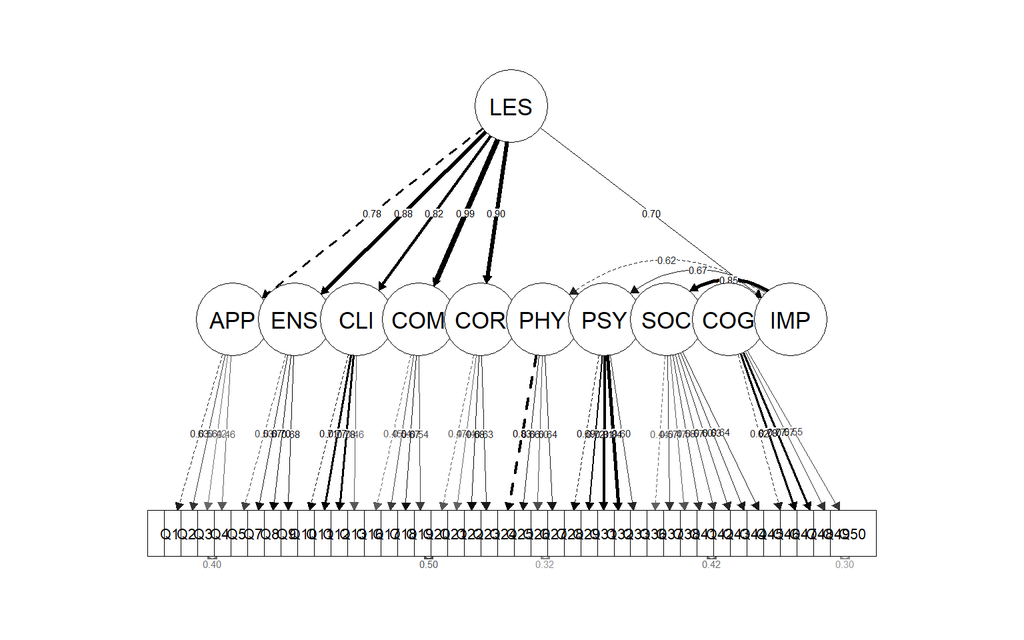

```r
semPaths(object = lesson.fittt,
         layout = "tree",
         rotation = 1,
         whatLabels = "std",
         edge.label.cex = 0.5,
         what = "std",
         residuals = F,
         edge.color = "black")
```